# White Wine Quality Exploration by Eric Jones

This report explores a dataset containing information about White Wines. Specifically, the data include chemical measures as well as a subjective `quality` measure assigned by an expert panel. More details about each of the measures can be found in the [documentation] (https://s3.amazonaws.com/udacity-hosted-downloads/ud651/wineQualityInfo.txt).

```
## 'data.frame':    4898 obs. of  12 variables:
##  $ fixed.acidity       : num  7 6.3 8.1 7.2 7.2 8.1 6.2 7 6.3 8.1 ...
##  $ volatile.acidity    : num  0.27 0.3 0.28 0.23 0.23 0.28 0.32 0.27 0.3 0.22 ...
##  $ citric.acid         : num  0.36 0.34 0.4 0.32 0.32 0.4 0.16 0.36 0.34 0.43 ...
##  $ residual.sugar      : num  20.7 1.6 6.9 8.5 8.5 6.9 7 20.7 1.6 1.5 ...
##  $ chlorides           : num  0.045 0.049 0.05 0.058 0.058 0.05 0.045 0.045 0.049 0.044 ...
##  $ free.sulfur.dioxide : num  45 14 30 47 47 30 30 45 14 28 ...
##  $ total.sulfur.dioxide: num  170 132 97 186 186 97 136 170 132 129 ...
##  $ density             : num  1.001 0.994 0.995 0.996 0.996 ...
##  $ pH                  : num  3 3.3 3.26 3.19 3.19 3.26 3.18 3 3.3 3.22 ...
##  $ sulphates           : num  0.45 0.49 0.44 0.4 0.4 0.44 0.47 0.45 0.49 0.45 ...
##  $ alcohol             : num  8.8 9.5 10.1 9.9 9.9 10.1 9.6 8.8 9.5 11 ...
##  $ quality             : int  6 6 6 6 6 6 6 6 6 6 ...
```

There are nearly 5000 wines included in the data, with 12 variables.

# Univariate Plots Section

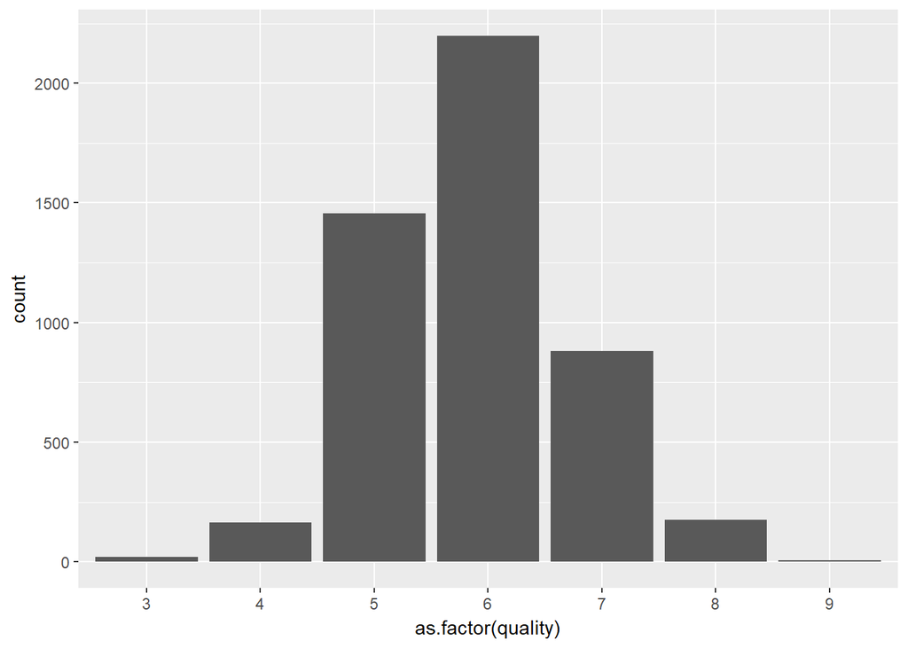

```
##    Min. 1st Qu.  Median    Mean 3rd Qu.    Max.
##   3.000   5.000   6.000   5.878   6.000   9.000
```

The subjective rating `quality` roughly normally distributed, with a range between 3 and 9. What are the characteristics that help a wine earn a rating over 6?

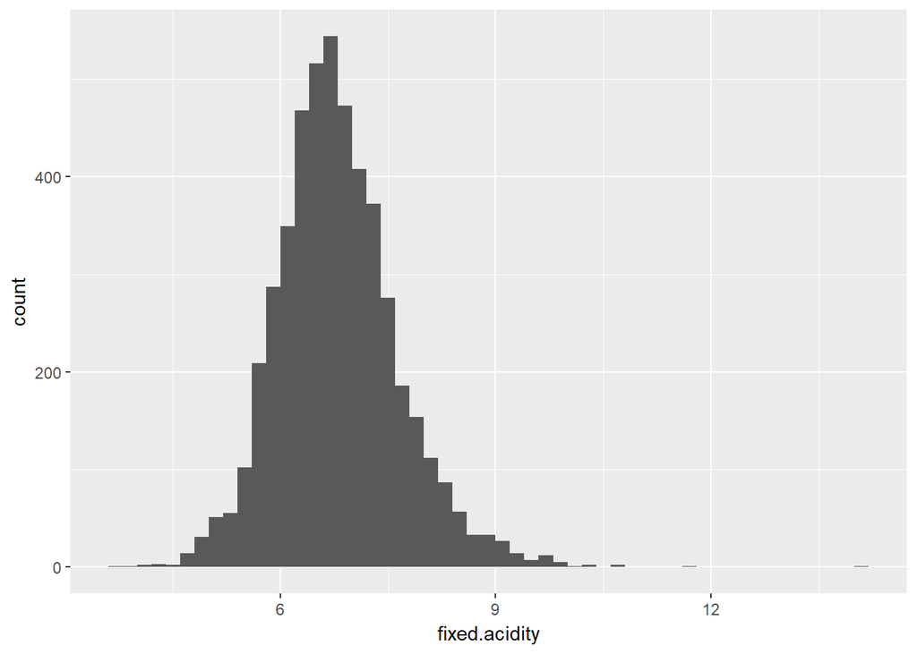

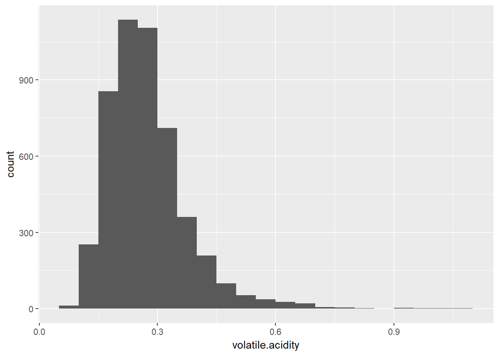

Fixed acidity is roughly normal, while volatile acids have a bit of a long tail. This may be worth further investigation, as the data notes indicate high levels can lead to an “unpleasant vinegar taste.”

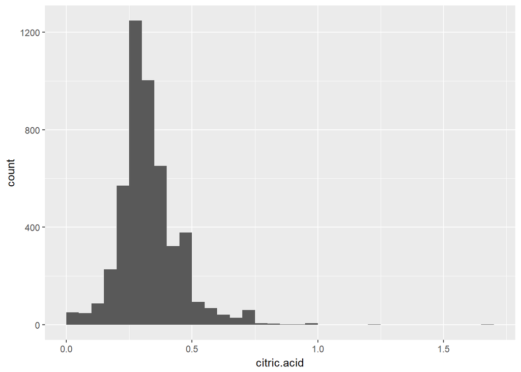

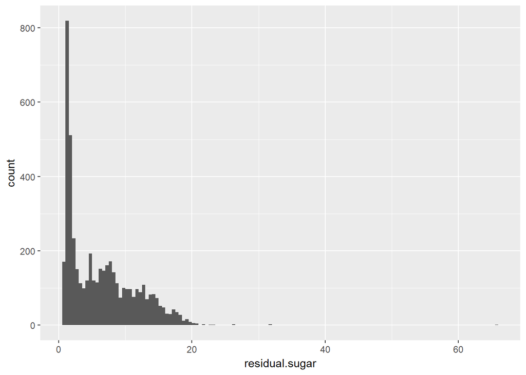

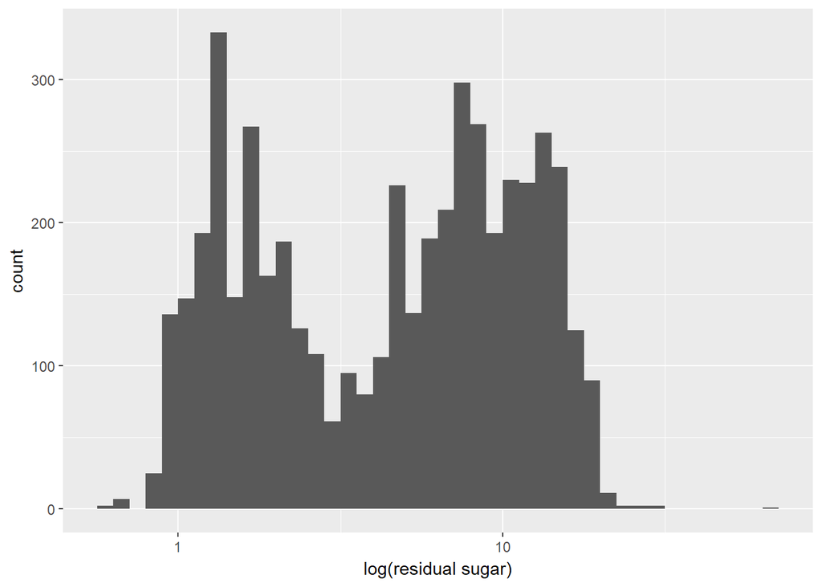

Residual sugar shows a heavy skew to the right. A large number of wines have only about 1g/L of residual sugar, but the remainder have values across the range up to about 20g/L, and a few higher. On a log scale, a bi-modal distribution is revealed.

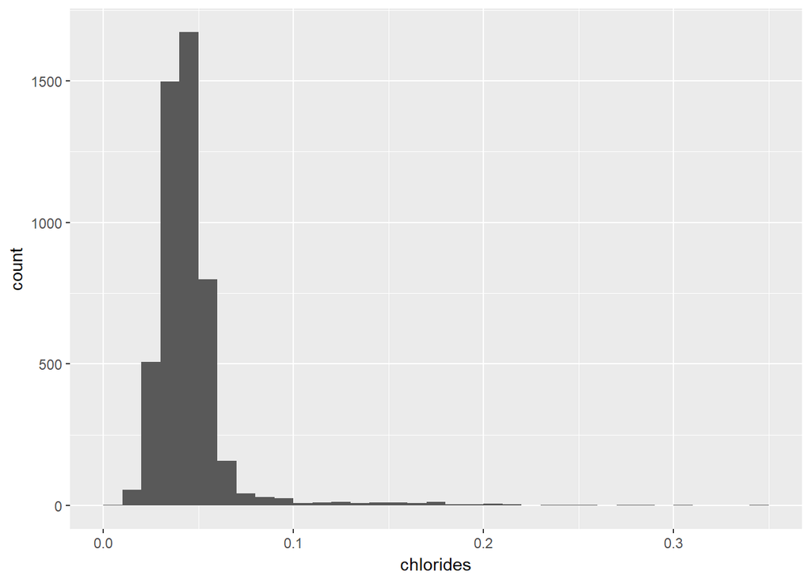

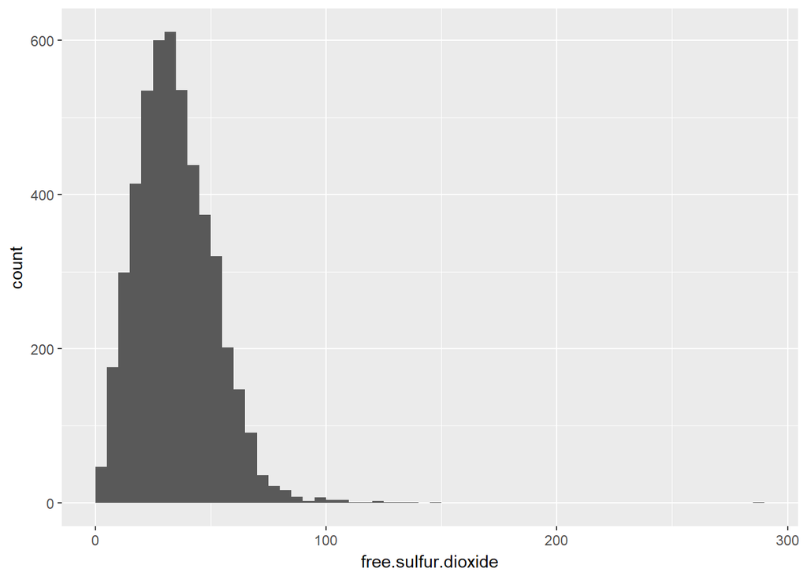

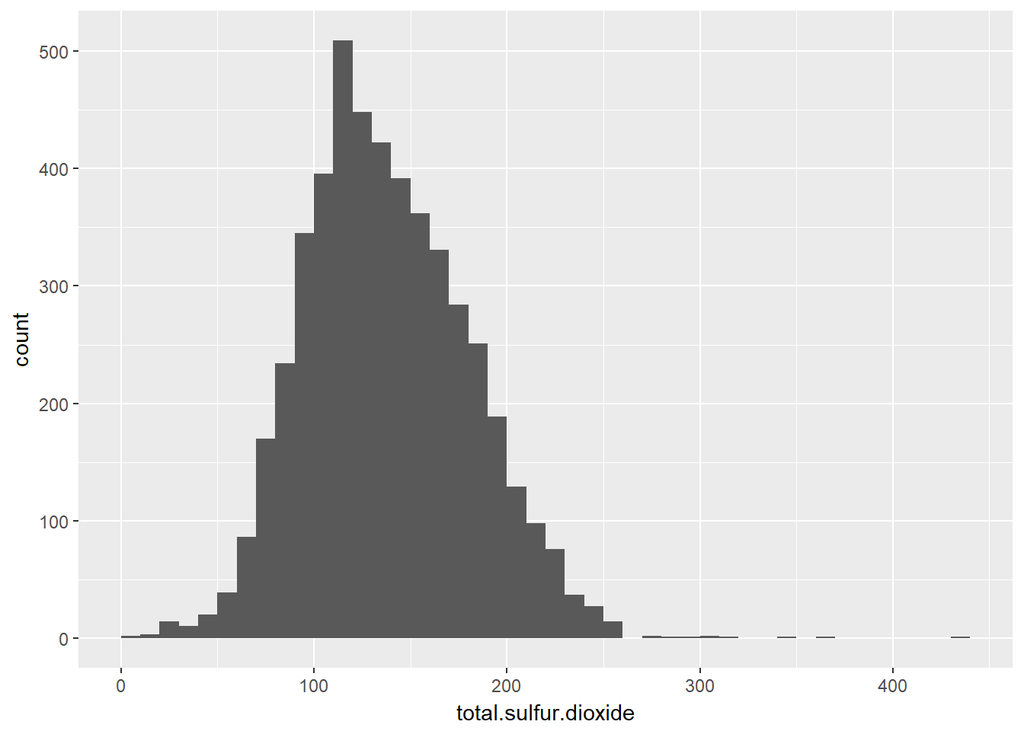

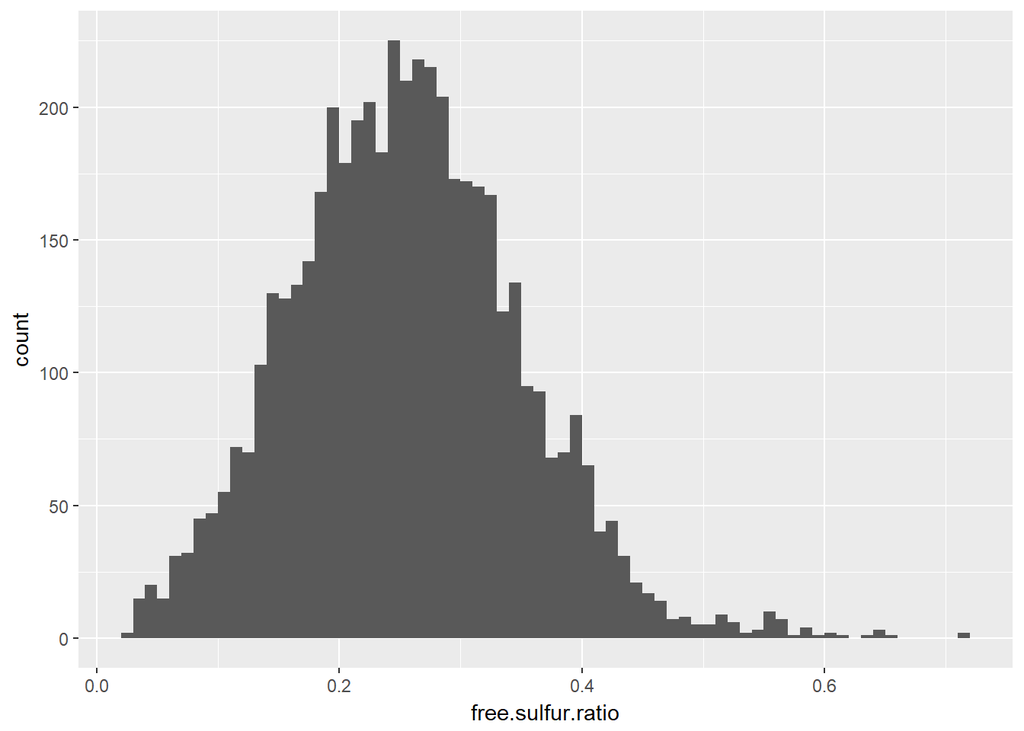

Free sulfur ratio may be a better way to investigate the sulfur dioxide levels, as the total measurement is simply the free plus the bound SO2. The ratio takes a more normal distribution than either of its factors.

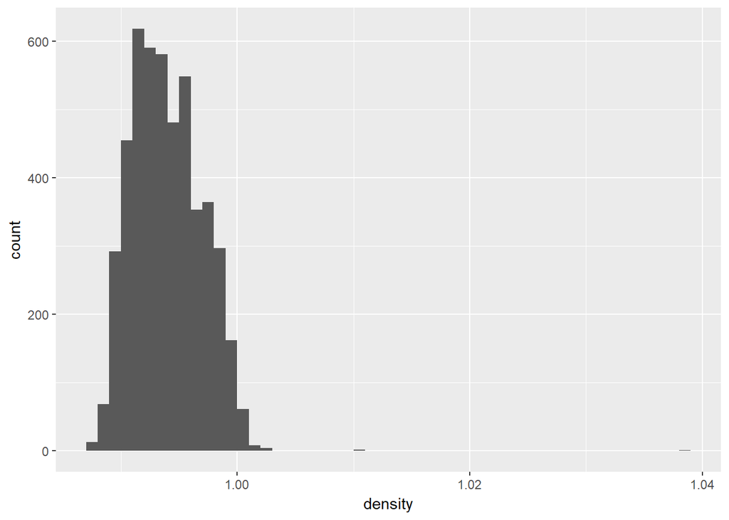

A few wines are more dense than water (1), which seems odd as alcohol is less dense than water. Most are slightly less dense than water. Do other measures help explain this? How do these wines rate?

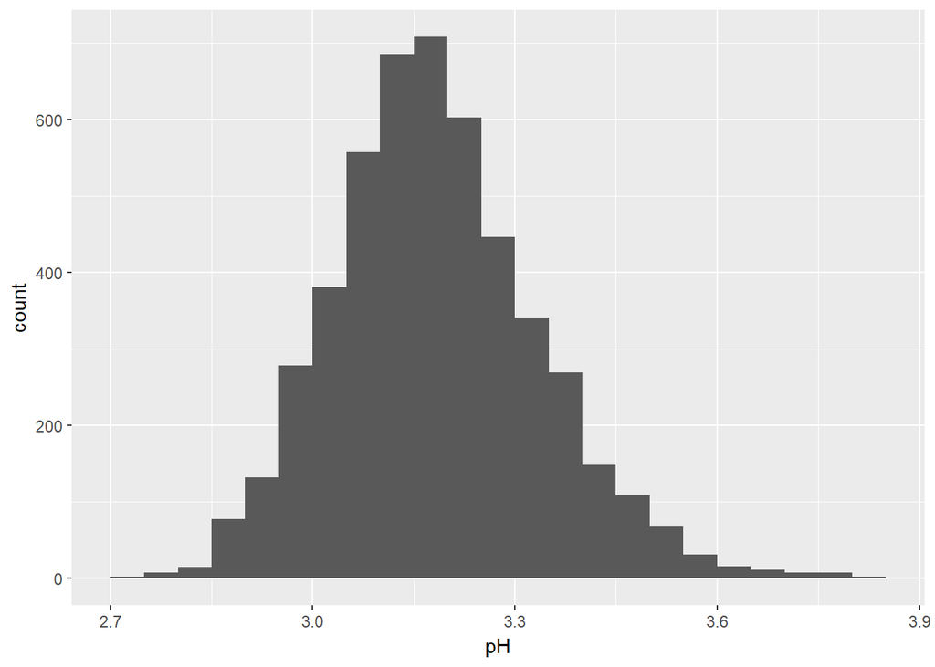

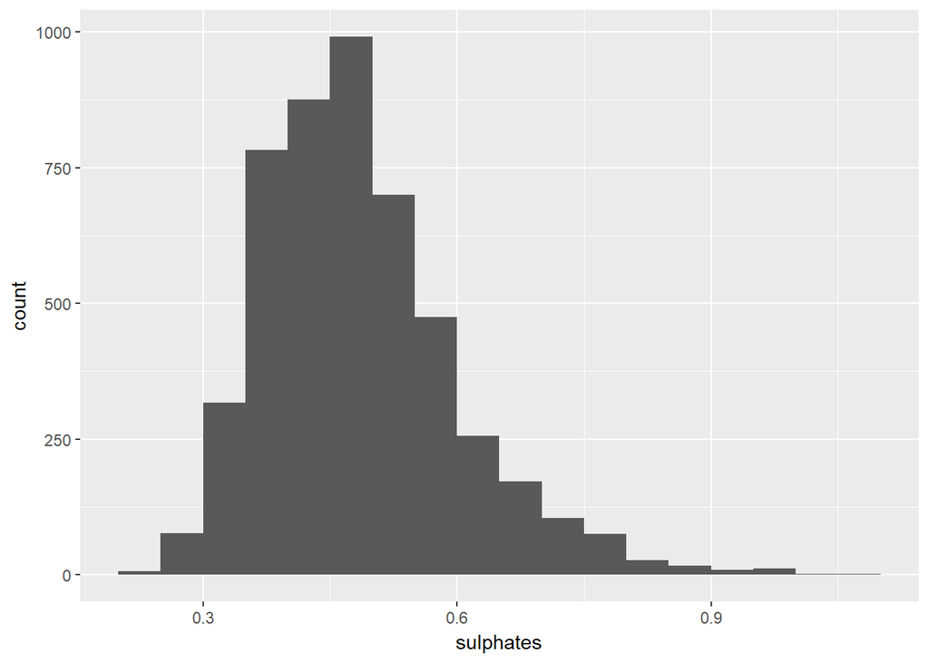

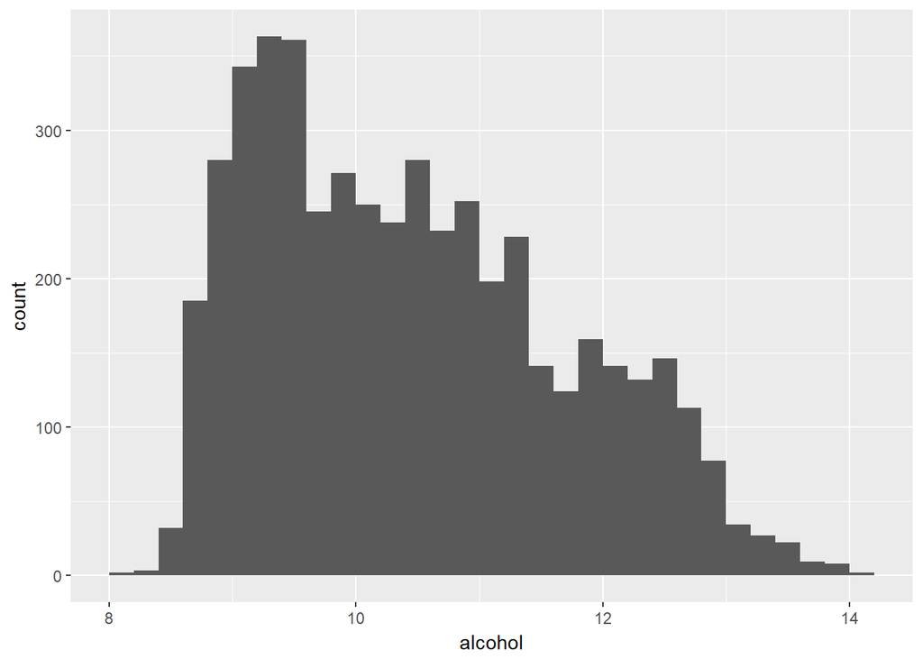

Alcohol levels appear almost closer to a uniform distribution rather than a normal distribution. How does alcohol level affect quality? Are any of the other chemical measures highly correlated with abv?

# Univariate Analysis

### What is the structure of your dataset?

There are 4898 observations of 12 variables: 11 chemical measures and a quality rating.

### What is/are the main feature(s) of interest in your dataset?

I’m most intersted in seeing how each of the different chemical measures correlates with quality. I suspect some combination of a subset of the measures can predict quality.

### What other features in the dataset do you think will help support your investigation into your feature(s) of interest?

While I know very little about wine, from reading the data information, I suspect that acidity levels could be a large contributing factor.

### Did you create any new variables from existing variables in the dataset?

I made a free sulfur ratio variable which is simply the free sulfur dioxide measurement divided by the total sulfur dioxide measurement.

### Of the features you investigated, were there any unusual distributions? Did you perform any operations on the data to tidy, adjust, or change the form of the data? If so, why did you do this?

# Bivariate Plots Section

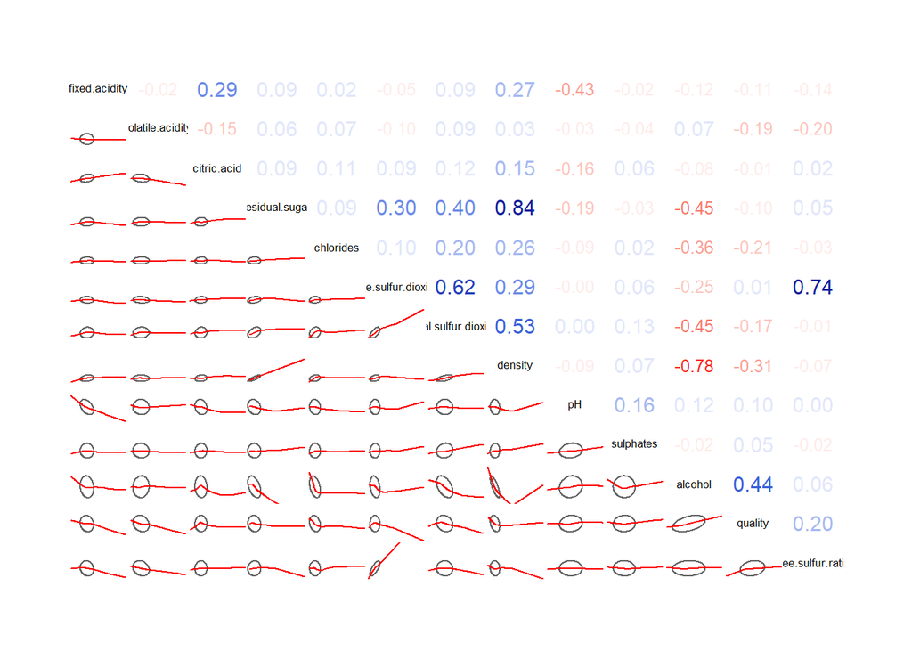

Total sulfur dioxide correlates with free sulfur dioxide. That’s not very surprising.

Density correlates with residual sugar and negatively with alcohol. Ah Sugar! This is expected. The correlation with alcohol is also expected. There is also a slight correlation with total sulfur dioxide. I know less about that chemistry.

Quality correlates with alcohol, and no other observation has much of a direct relation to quality. This seems very supicious, but maybe there are combinations of observations that lead to quality. This could also mean that there are a lot of diffrent combinations which make great wine, and it is typically also higher in alcohol.

Looking closer at each of these relationships:

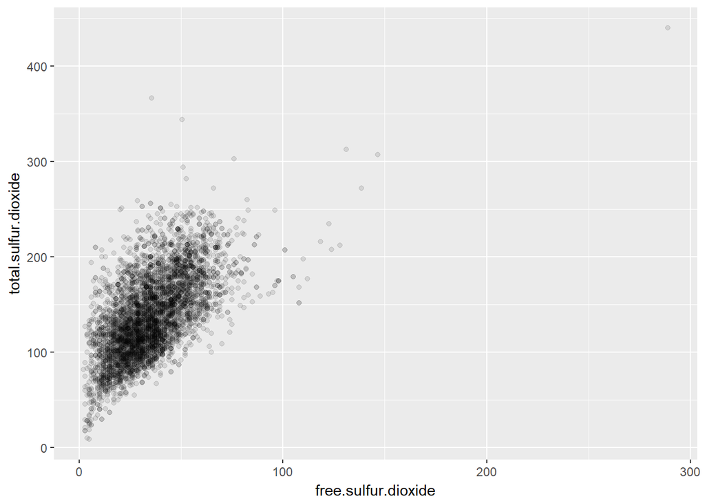

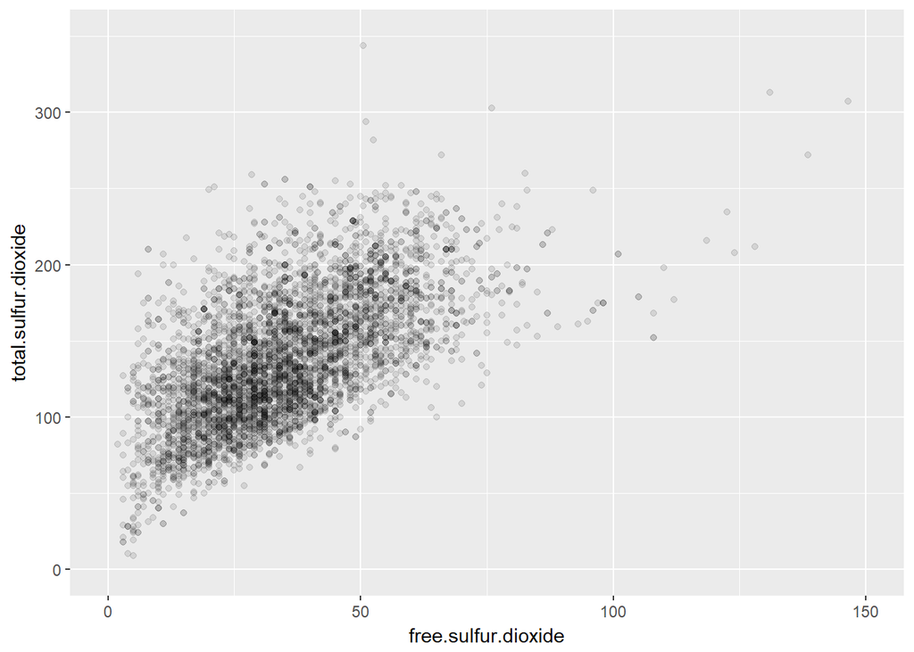

All points are above the 1:1 line and there is a correlation as expected when `total` is `free` plus other.

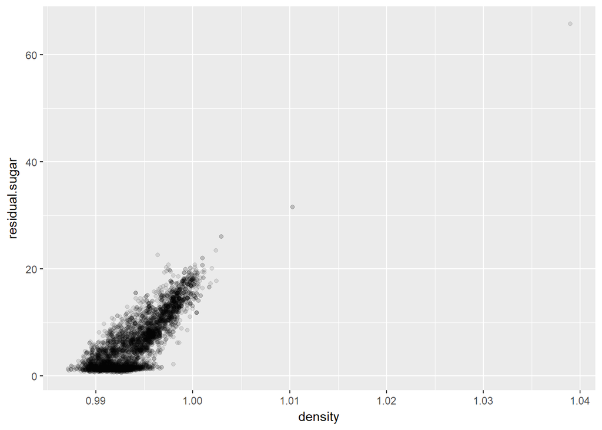

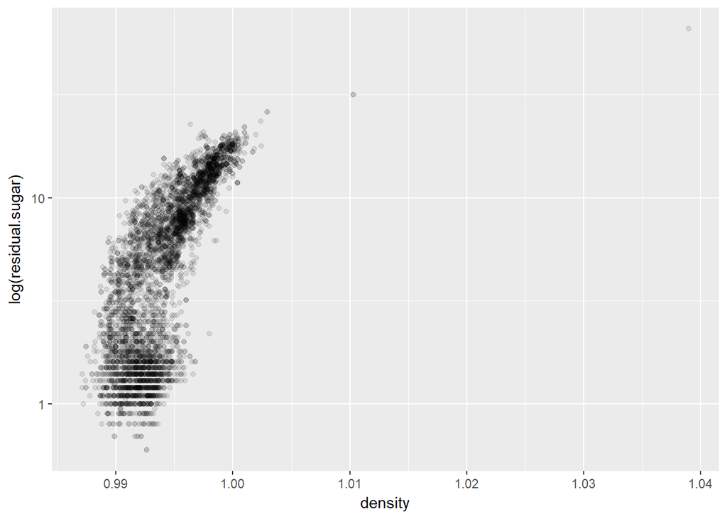

Most wines have similar density just under 1 and low sugar, but higher sugar correlates with increased density. This is just chemistry.

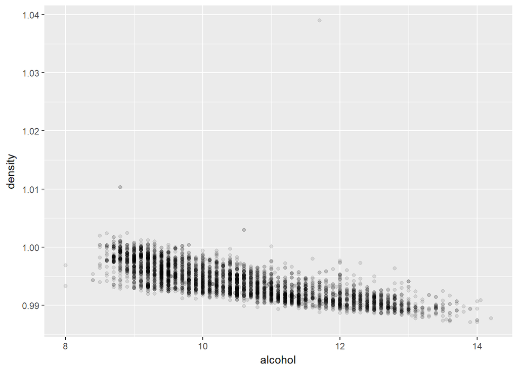

Another simple chemistry observation, higher alcohol content correlates with lower density. I suspect a combination of alcohol and sugar explains most of the variation in density. But is density actually important for quality?

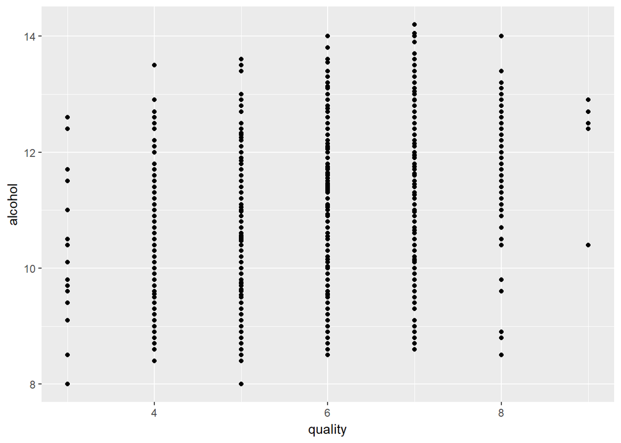

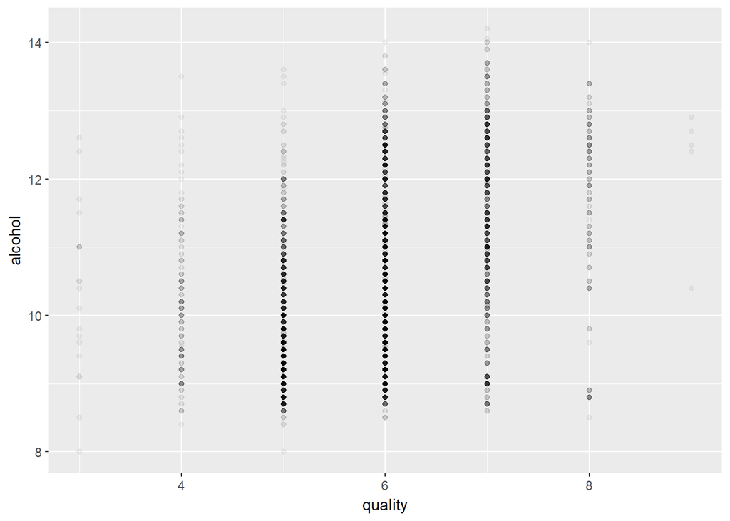

Even when turning the alpha value down so that single points barely show up, the trend is hard to see.

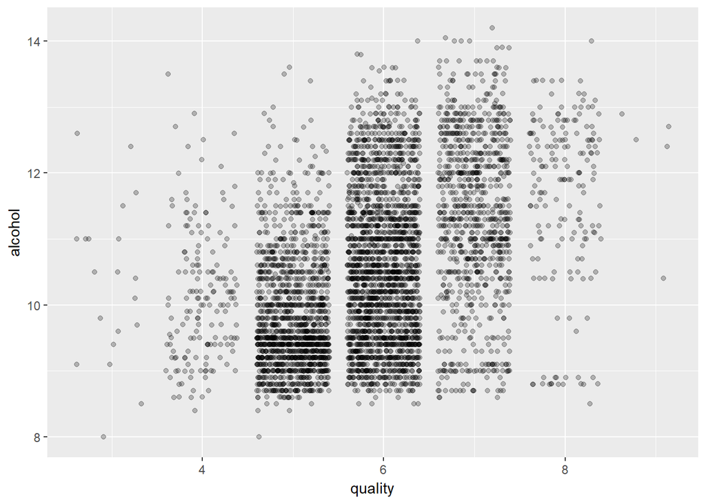

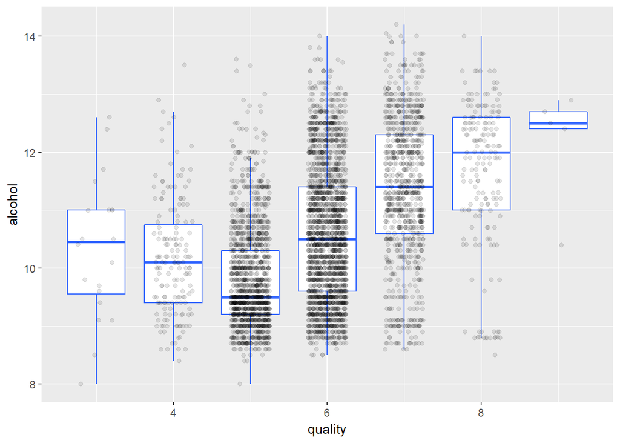

Setting jitter helps some, but I think the easiest way to see the trend is with a set of box plots. There is, of course, a range of alcohol levels at each quality rating, but the trend from the percentiles shown by the boxes is clear.

# Bivariate Analysis

### Talk about some of the relationships you observed in this part of the investigation. How did the feature(s) of interest vary with other features in the dataset?

Quality has a reasonably stong correlation (Pearson’s r = 0.44) with alcohol content. I was surprised to find that quality did not correlate strongly with any other single variable in the dataset.

### Did you observe any interesting relationships between the other features (not the main feature(s) of interest)?

Density correlates with residual sugar and with alcohol content, which can be explained by chemistry.

### What was the strongest relationship you found?

# Multivariate Plots Section

First, take a quick look at the density chart for alcohol by quality, which is a bit more descriptive than the box plots seen in the previous section.

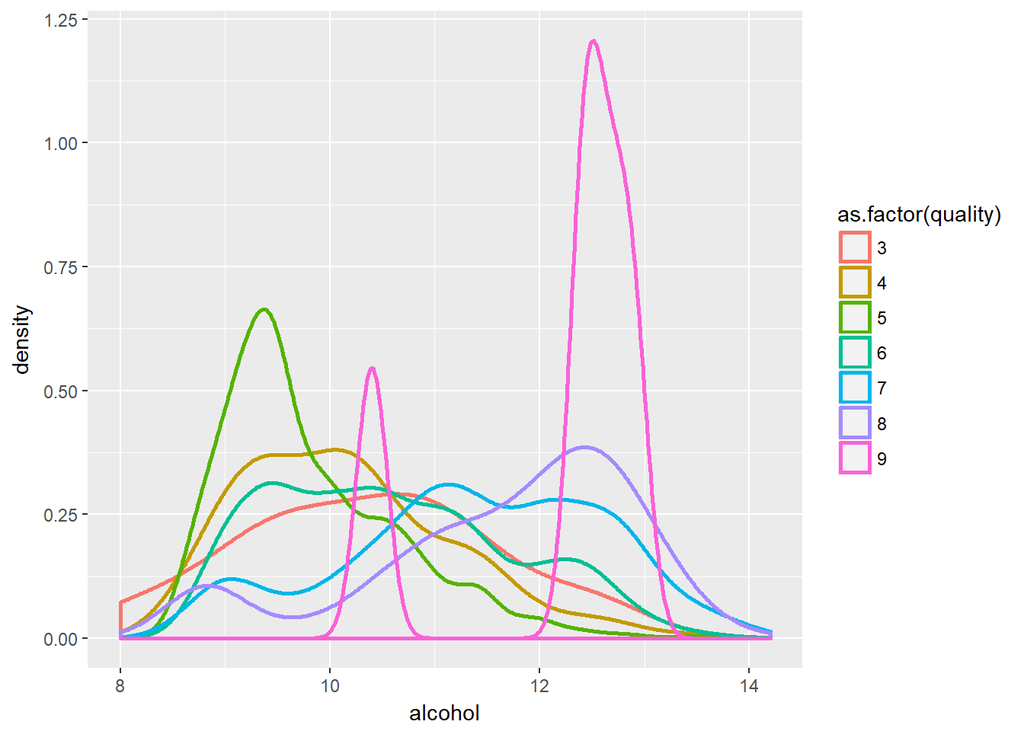

There are only a few wines rated 9 so the density spikes are tall. Other quality ratings show the trends seen in the box plots: lower quality tend to be lower alcohol, higher quaitly tends to be higher alcohol.

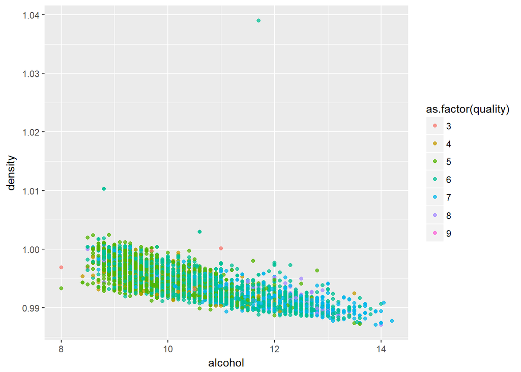

We already know alcohol and density are strongly correlated, but it’s a little hard to see if there is anything more going on here. I zoomed in the y axis and changed the color scheme to color points with quality 6 or higher more vividly.

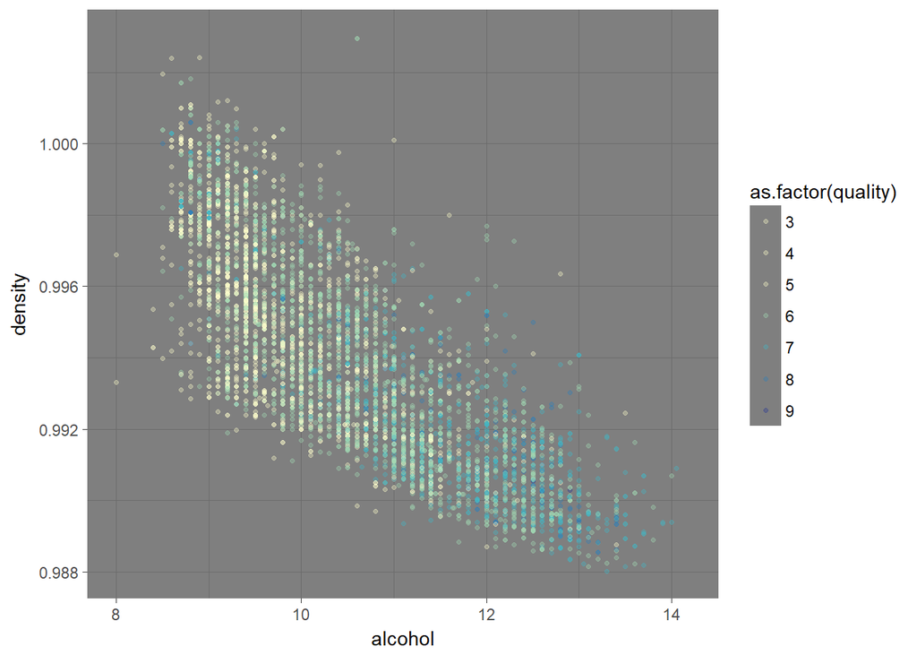

On this chart, it’s easier to see that density at a given alcohol level doesn’t have much effect on quality. Alcohol is the dominant factor.

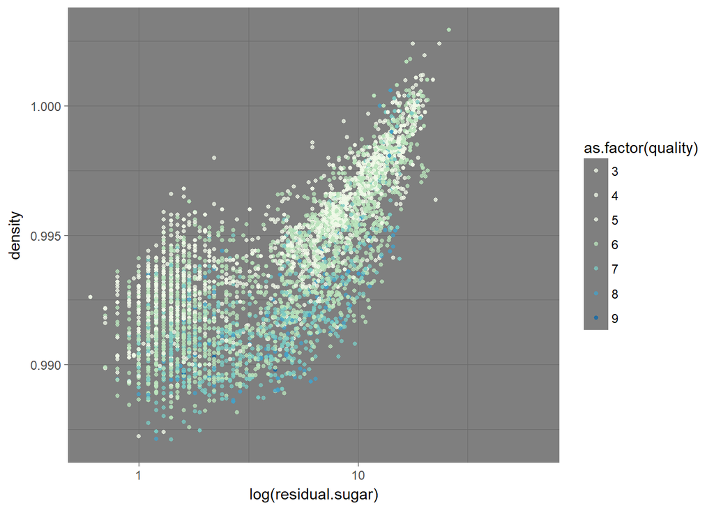

At a given value for residual sugar, there are wines of many different quality ratings, but typically, less dense wines rate better than more dense. It follows from previous observations we know density and alcohol have an inverse relation, so more alcoholic wines rate higher at the same sugar value.

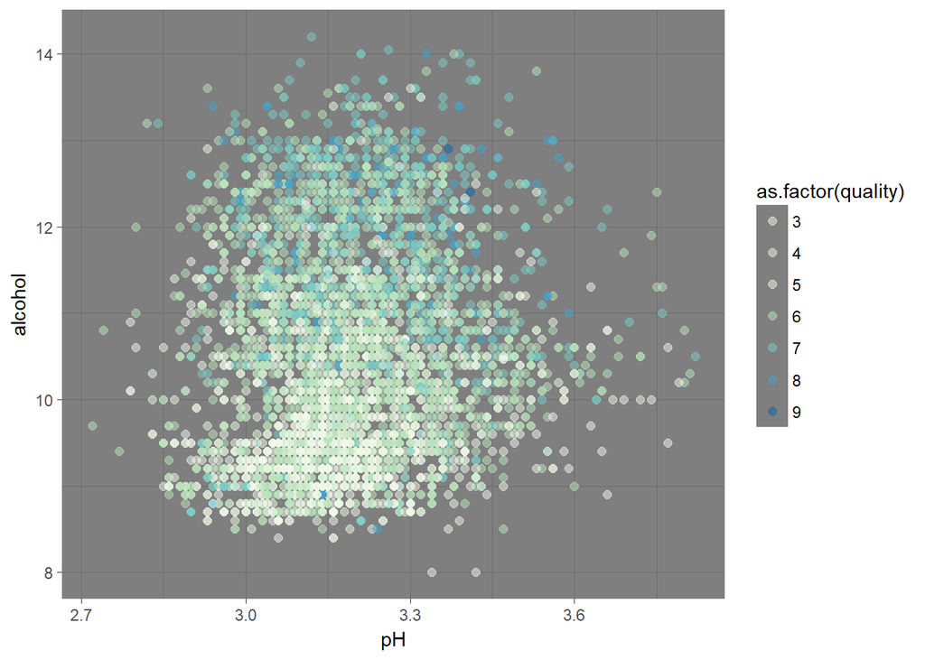

Looking at pH as a proxy of acidity values, again alcohol is a dominant factor in determining quality. This all follows from the correlation matrix.

# Multivariate Analysis

### Talk about some of the relationships you observed in this part of the investigation. Were there features that strengthened each other in terms of looking at your feature(s) of interest?

Alcohol level really is the dominating factor when trying to determine quality. This really makes me question the human-assigned quality ratings. Is it more difficult or expensive to make more alcoholic wines?

### Were there any interesting or surprising interactions between features?

Generally, features followed relationships that my basic chemsiry knowledge agrees with. I’m not a wine drinker, so I can’t comment on how the chemical measures affected the quality rating, just that the relationships between the chemical measures appeared to be accurate. I’m surprised that no chemical measure besides alcohol correlated strongly with quality, but suspect some combination of the measures may correlate, though finding that combination is out of scope for this project.

# Final Plots and Summary

### Plot One

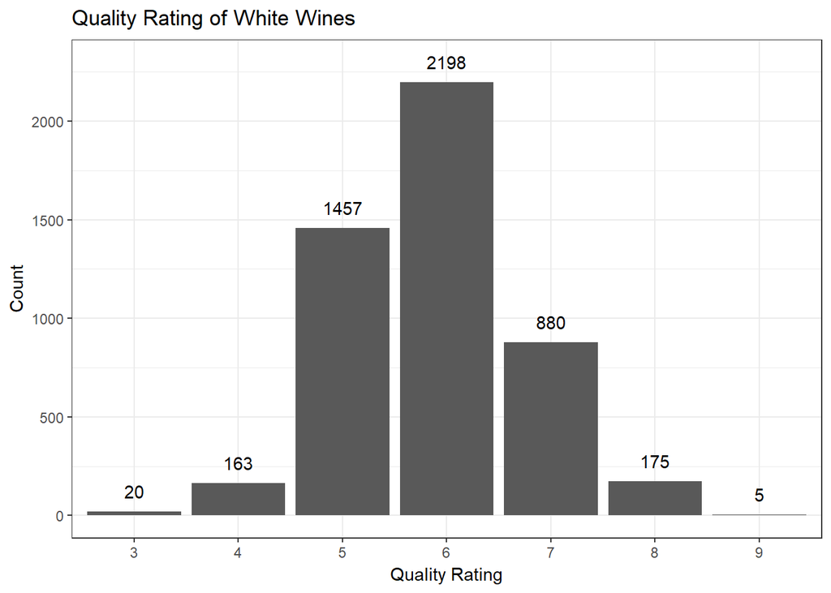

### Description One

The distribution of quality ratings is roughly normal, with nearly half (44.9%) of the wines scoring a quality rating of 6, and only 3.7% scoring an 8 or 9.

### Plot Two

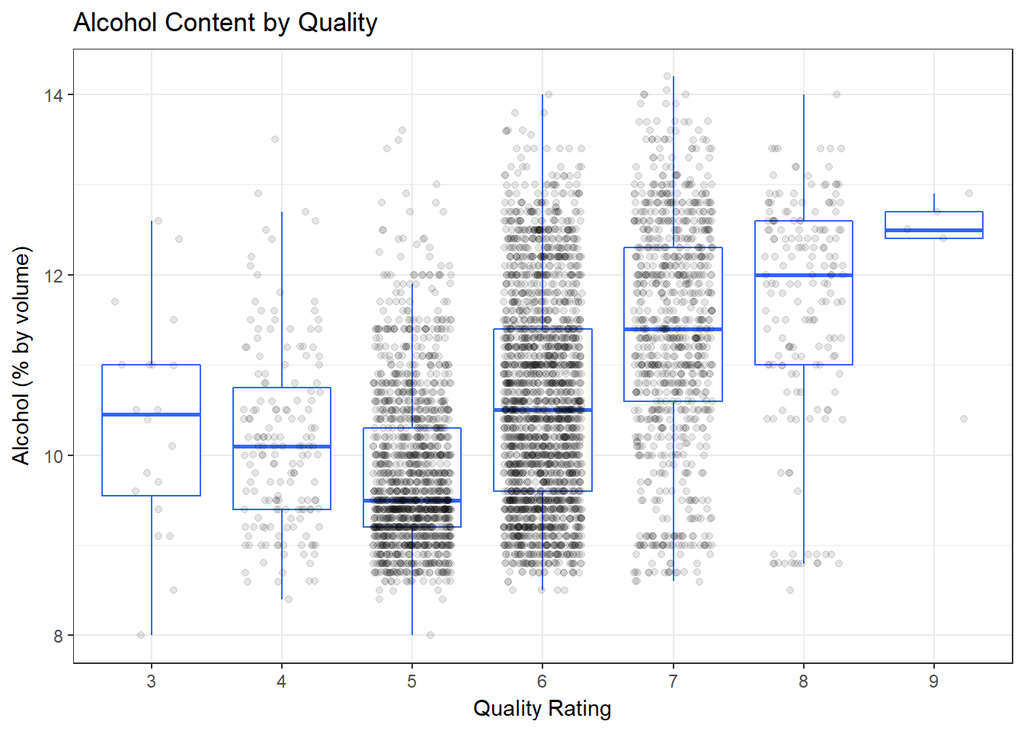

### Description Two

Alcohol content is stronly correlated with quality. While wines ranking a 6 (the median) were of many abv levels, wines ranking 7 or above tended to be more alcoholic, while wines ranking 5 or lower tended to be less alcoholic. Of the five wines rated a 9, four have an abv above 12.

### Plot Three

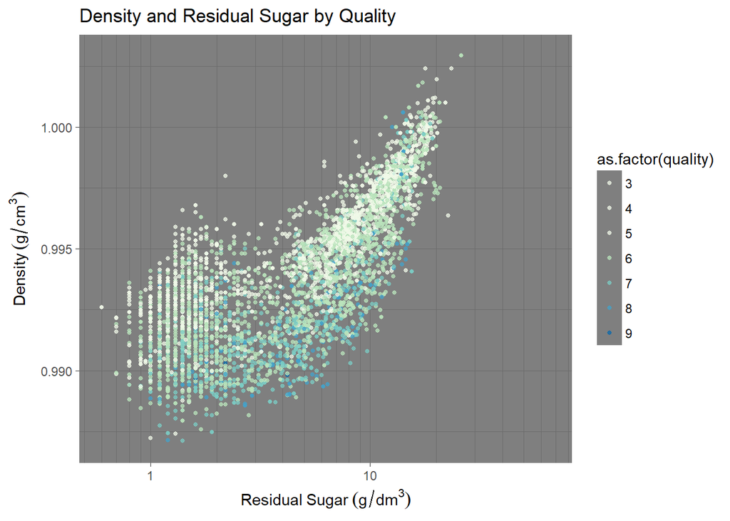

### Description Three

Wines ranked higher than 6 span the values of residual sugar, but for a given sugar value, the less dense wines rate higher.

# Reflection

There are nearly 5000 wines covered in this dataset, and chemically they are quite varried. As there was one specific output variable included in the data (`quality`), I knew I would be looking for which of the other measures were correlated with that value.

I was happy that the quality ratings were about normal, but then very surprised to find that no individual chemical measurement other than alcohol level was strongly correlated with the quality rating.

One challenging thing with this data was that very few individual measures were correlated, so it was difficult to find an interesting story. To further this investigation, I would want to develop a model, possibly using machine learning, in order to see if a combination of chemical measures can predict quality ratings. It would be interesting to see if a model can be created that does not use alcohol as one of the variables and is still able to predict quality well. Otherwise, I would have to conclude that the (human) quality review team just likes to get drunk.